# Steelhead Passage through Bonneville Dam, Oregon

Gabriel De La Rosa

2/18/2020

## Introduction

Bonneville Dam, Oregon has collected 80 years of steelhead counts from its fish ladder, beginning in 1939. Steelhead are sea run rainbow trout (*Oncorhynhus mykiss*), and were significantly affected by dam development and river alteration in the 20th century. Here, I explore counts of the endangered species over all years for the Bonneville Dam.

Data was provided by the [University of Washington DART](http://www.cbr.washington.edu/dart/metadata/adult) program, and collected by the [Army Corps of Engineers](https://www.nwd.usace.army.mil/).

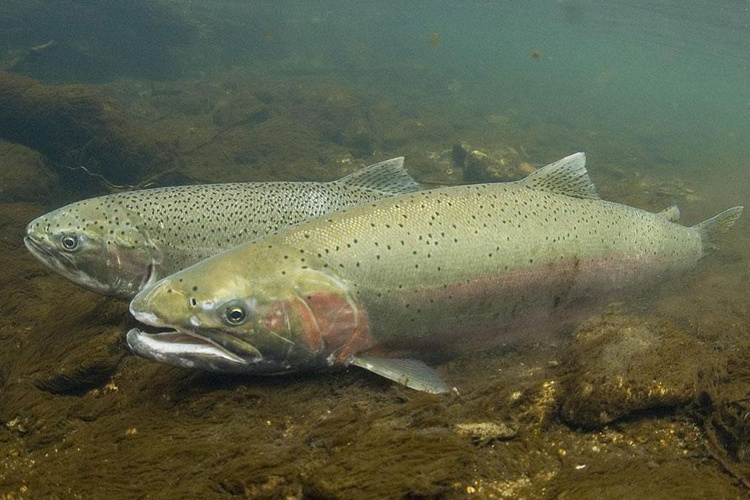

Steelhead trout. Photo: NOAA Fisheries

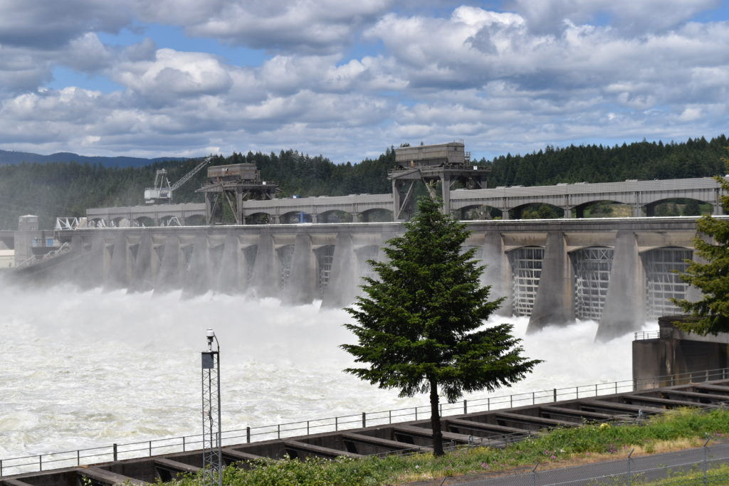

Bonneville Dam,Oregon. Photo: Richard Walker

```r
fish <- read_csv(here("data", "cbr_fish_passage_bonneville_allyrs_steelhead.csv")) %>%
  clean_names()
```

```r
# Clean up these dates with the lubridate:: package
fish_clean <- fish %>%
  mutate(day_month = str_c(fish$year, fish$mm_dd, sep = '-')) %>%
  mutate(date = lubridate::ydm(day_month)) %>%
  mutate(year = lubridate::year(date)) %>%
  mutate(month = lubridate::month(date, label = TRUE)) %>%
  drop_na()
```

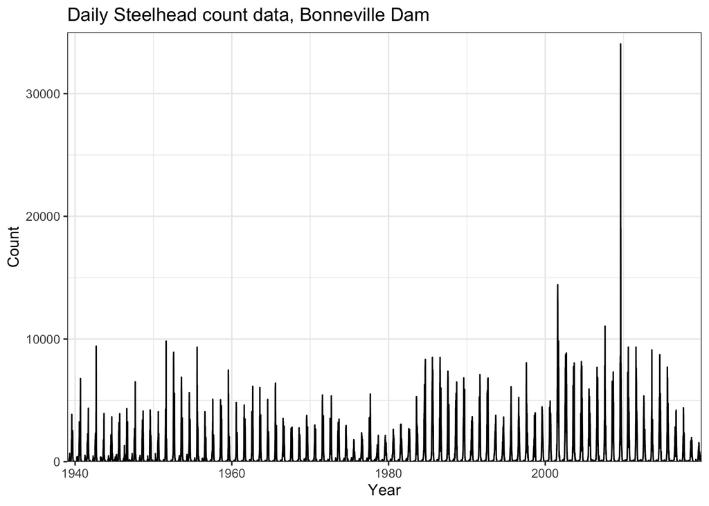

**Fig. 1** *Daily counts for steelhead at the Bonneville Dam for all years.*

```r
daily_ct <- ggplot(data = fish_clean, aes(x = date, y = value)) +
  geom_line() +
  theme_bw() +
  scale_x_date(expand = c(0,0)) +
  scale_y_continuous(expand = c(0,0), limits = c(0, 35000)) +
  labs(title = "Daily Steelhead count data, Bonneville Dam", x = "Year", y = "Count")

ggsave("daily_ct.png", plot = daily_ct)
```

A plot of daily counts over the whole time frame suggests that steelhead passage is seasonal.Each year appears to have a spike where steelhead migration is high. We can explore seasonality in a season plot:

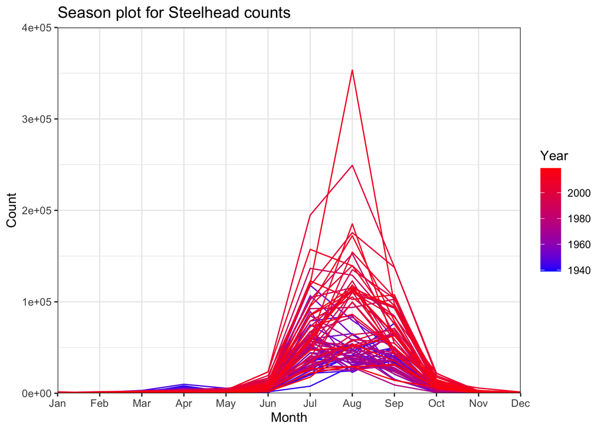

**Fig 2.** *Season plot for steelhead counts. Each line represents one year of data. Counts are total counts per month. Data from 1939-2019.*

```r
# First, make a summary data frame with total counts per date and parsed year and month

fish_count <- fish_clean %>%
  group_by(date) %>%
  summarize(value = sum(value)) %>%
  mutate(year = year(date),
         month = month(date, label = TRUE)) %>%
  mutate(month_sep = str_c(year, month, sep = '-')) %>%
  mutate(y_m = tsibble::yearmonth(month_sep))

## Let's take monthly means so it's clearer...

fish_sum <- fish_count %>%
  group_by(year, month) %>%
  summarize(value = sum(value)) %>%
  mutate(month_sep = str_c(year, month, sep = '-')) %>%
  mutate(y_m = tsibble::yearmonth(month_sep))

# Then, plot it as a season plot!

season_plot <- ggplot(data = fish_sum, aes(x = month, y = value, group = year)) +
  geom_line(aes(color = year)) +

  scale_color_continuous(low = "blue", high = "red") +

  scale_x_discrete(expand = c(0,0)) +
  scale_y_continuous(limits = c(0,400000), expand = c(0,0)) +

  theme_bw() +
  labs(title = "Season plot for Steelhead counts",
       x = "Month",
       y = "Count",
       color = "Year")

ggsave("season.png", plot = season_plot)
```

A season plot shows that steelhead pass through the Bonneville Dam mainly during summer months. It also indicates that steelhead counts have changed through the years, and seem more abundant recently. We can explore this by plotting yearly counts:

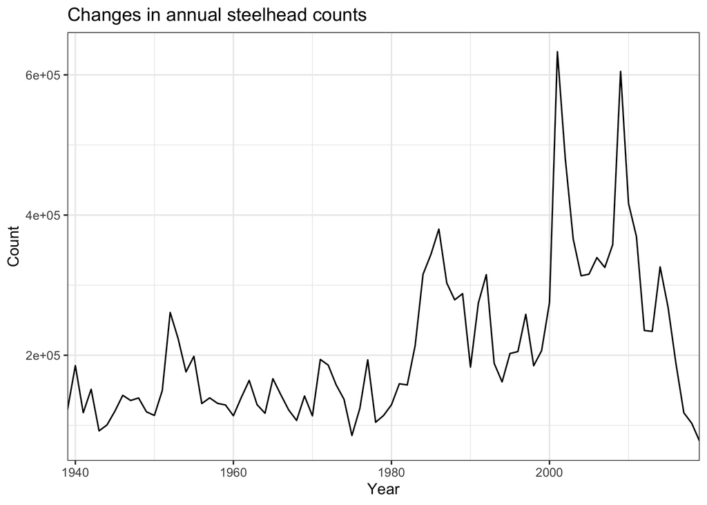

**Fig 3.** *Total steelhead counts per year*

```r
# What about annual counts?

fish_ann <- fish_count %>%
  group_by(year) %>%
  summarize(count = sum(value))

ann_ct <- ggplot(fish_ann, aes(x = year, y = count)) +
  geom_line() +
  theme_bw() +
  labs(title = "Changes in annual steelhead counts",
       x = "Year", y = "Count") +
  scale_x_continuous(expand = c(0,0))

ggsave("ann_ct.png", plot = ann_ct)
```